# KapitalneRemonty

*Projekt całej bazy wykonał team5 składający się z: Jana Solarza, Pawła Matławskiego, Aleksandra Kaczmarka i Michała Liszkowskiego*

## 1.Projekt i schemat bazy

*Stworzyliśmy bazę, która składa się z siedmiu tabel. Są nimi:*

**1.** **tabela Zlecenia**

Składa się z 30 unikatowych zleceń. Daty 9999-12-31 oznaczają trwanie danego okresu do dnia dzisiejszego. Jest to tabela główna, która składa się z:

**2.** **tabela Klienci**

Składa się z 80 unikatowych klientów. Tabela zawiera niezbędne informacje dotyczące klientów naszej firmy, składa się ona z:

- ID_klienta- klucz główny
- Imię_i_nazwisko
- Numer_telefonu
- Ulica
- Nr_domu
- Nr_mieszkania
- Kod_pocztowy
- Ankieta- zmienna informująca firme o tym w jaki sposób klient się o nas dowiedział. Rozpatrujemy ulotkę, reklamę internetową, znajomi i sposób przypadkowy

**3.** **tabela Sprzęt**

Składa się z 34 przedmiotów jakie zakupiła nasza firma w celu realizaji remontów. Mamy zmienne takie jak:

- ID_sprzętu
- Leasing- wartość true mówi nam że sprzęt jest leasingowany, natomiast gdy false sprzęt został zakupiony za gotówkę
- Typ- odnosi się do typu narzędzi wykorzystywanych w pracach, ale również samochodów oraz przyczep jakie firma posiada, odzieży i akcesoriów
- Data_zakupu
- Koszt_zakupu- Jest to kwota netto zakupu sprzętu

**4.** **tabela Pracownicy**

Składa się z 24 pracowników o narodowości ukraińskiej. Zatrudniani byli od 2010 roku, czyli odkąd istnieje firma. Około połowa z nich jest współpracuje z nami do dziś. Tabela składa się z:

- ID_pracownika
- Imie_i_nazwisko
- Nr_telefonu- są to numery firmowe, więc pierwsze 6 cyfr numerów są takie same
- Doswiadczenie- jest to łączna ilość lat doświadczenia w branży przed pracą u nas w firmie wraz z czasem, który pracownik spędził w KapitalneRemonty
- Data_zatrudnienia
- Koniec_zatrudnienia
- Pensja- wyliczana na podstawie lat doświadczenia poprzez odpowiednie współczynniki determinujące lata przepracowane u nas w firmie i poza nią.

**5.** **tabela pracownicy_zlecenia**

Składa się z 15 unikatowych zespołów pracowników, którzy są przydzielani odpowiednio do danego zlecenia. Są oni dobierani na podstawie uzyskanego doświadczenia w zawodzie.

- ID_teamu- indeks "a" determinuje 3 pracowników do zlecenia (typ zlecenia *remont ogólny* i *elewacja*), indeks "b" 2 pracownicy (*remont kuchni*, *remont łazienki), indeks "c"* malowanie*,* remont pokoju*)
- ID_pracownika1
- ID_pracownika2
- ID_pracownika3

**6.** **tabela Adres_zlecenia**

Składa się z adresów zleceń, które są wykonywane w 2020 roku. Część adresów to miejsca zamieszkania klientów, a część to nieruchomości które posiadają. Są to adresy z konkretnego obszaru, na którym działa firma (okolice Wrocławia).

- ID_adresu- klucz główny
- ulica
- nr_domu
- nr_mieszkania
- kod_pocztowy
- piętro
- ID_klienta- klucz obcy

**7.** **tabela kod_pocztowy**

- kod_pocztowy
- miasto

##### Relacje

- Relacja tabela Zlecenia i Klienci: "Zero One N" jeden klient w roku 2020 może być zleceniodawcą żadnego, jednego lub wielu remontów, natomiast jedno zlecenie jest zawsze przyporządkowane do jednego klienta.
- Relacja tabela Zlecenia i adres_zlecenia: "One N" jeden adres zlecenia musi być przypisany co najmniej do jednego zlecenia.
- Relacja tabela Klienci i Kod_pocztowy: "Zero One N" pod jeden kod pocztowy może być podpięty zero, jeden lub wielu klientów.
- Relacja tabela Kod_pocztowy i adres_zlecenia: "Zero One N" pod jeden kod pocztowy może być podpięte zero, jedno lub wiele zleceń.
- Relacja tabela Pracownicy i pracownicy_zlecenia: "Zero One N" pracowik może nie być przypisany do żadnego, jednego lub wielu teamów. Robimy takie trzy identyczne relacje, ponieważ teamy są max trzyosobowe.
- Relacja tebla Pracownicy i Zlecenia: "One Only" do jednego zlecenia przypisana jest dokładnie jeden zespół o unikatowym ID_teamu.
- Relacja tabela Klienci i adres_zlecenia: "Zero One N" (tak jak relacja Zlecenia i Klienci)

## 2. Skryptowe wypełnianie bazy

#### Kody zostały uwzględnione w pliku "Kody_wypełnianie_tabel"

## 3. Analiza danych

```python
import mysql.connector

mydb = mysql.connector.connect(
        host = 'giniewicz.it',
        user = 'team5',
        passwd = 't3@mSP@55',
        database = 'team5')

mycursor = mydb.cursor()
```

**1.** Wykres przedstawia liczbę zleceń oczekujących w roku 2020. Widzimy, że liczba zleceń osiąga maksymalnie wartość 5, ale nie można określić stałej tendencji co do zmiany wartości w czasie.

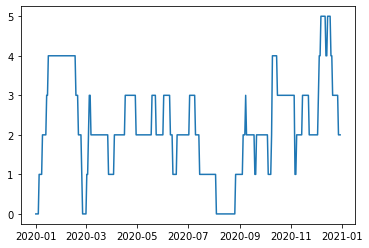

```python
import datetime
import matplotlib.pyplot as plt

sql_1 = "SELECT Data_otrzymania_zlecenia as order_time, Data_rozpoczęcia as start_time FROM Zlecenia"
mycursor.execute(sql_1)

myresult1 = mycursor.fetchall()

order_time = []
start_time = []

for x in myresult1:
    order_time.append(x[0])
    start_time.append(x[1])

x = [datetime.date(2020,1,1) + datetime.timedelta(days=i) for i in range(365)]
waiting_time = list(zip(order_time, start_time))

y = [0]*365

for i in range(365):
    for elem in waiting_time:
        if (elem[0] <= x[i]) and (elem[1] > x[i]):
            y[i]+=1
plt.plot(x, y)
```

**2.** Wykres przedstawia zmieniającą się liczbę zatrudnionych pracowników w czasie działalności firmy. Na podstawie wykresu możemy stwierdzić, że firma się "rozrasta", co świadczy o jej rozwoju.

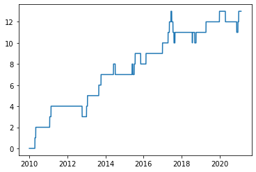

```python
sql_2 = "SELECT `Data_zatrudnienia`, `Koniec_zatrudnienia`\
FROM `team5`.`Pracownicy`"

mycursor.execute(sql_2)

myresult2 = mycursor.fetchall()

start = []
end = []

for x in myresult2:
    x = list(x)
    start.append(x[0])
    if x[1] == datetime.date(9999, 12, 31):
        end.append(datetime.date(2021, 2, 17))
    else:
        end.append(x[1])

daty = list(zip(start, end))

x = [datetime.date(2010,1,1) + datetime.timedelta(days=i) for i in range(4065)]

y = [0]*4065
for i in range(4065):
    for elem in daty:
        if (elem[0] <= x[i]) and (elem[1] > x[i]):
            y[i]+=1
plt.plot(x, y)
```

**3.** Wykres przedstawiający wartość zakupionego sprzętu w danym roku.

```
<BarContainer object of 6 artists>
```

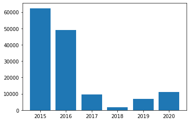

```python
sql_3 = "SELECT `Data_zakupu`, `Koszt_zakupu`\
FROM `team5`.`Sprzęt`"

mycursor.execute(sql_3)

myresult3 = mycursor.fetchall()


rok = []
kwota=[]


for element in myresult3:
    rok.append(element[0].year)
    kwota.append(element[1])

rok_kw = list(zip(rok,kwota))

x = [2015,2016,2017,2018,2019,2020]
y = [0,0,0,0,0,0]

for element in rok_kw:
    for i in range (len(x)):
        if element[0] == x[i]:
            y[i] += element[1]

plt.bar(x,y)
```

**5.** Na postawie zebranych odpowiedzi z ankiety informującej, w jaki sposób klienci dowiedzieli się o naszej firmie, możemy stwierdzić, że reklama internetowa jest najefektywniejszym "pozyskiwaczem" klientów.

```python
from statistics import mode

sql_5 = "SELECT Ankieta FROM Klienci"
mycursor.execute(sql_5)

myresult5 = mycursor.fetchall()
wyniki_ankiety = [ x[0] for x in myresult5]
odp_ankiety = []
for elem in wyniki_ankiety:
    if elem!= None:
        odp_ankiety.append(elem)
odp_ankieta = mode(odp_ankiety)
print(odp_ankieta)
```

```
reklama internetowa
```

**6.** Sprzętem najczęściej branym w leasing w czasie działalności firmy "KapitalneRemonty" jest samochód.

```python
sql_6 = "SELECT Leasing, Typ FROM Sprzęt"
mycursor.execute(sql_6)

leasing = []

myresult6 = mycursor.fetchall()
for elem in myresult6:
    if elem[0]==1:
        leasing.append(elem)
odp_leasing = mode(leasing)[1]
print(odp_leasing)
```

```
samochód
```

**8.** Pracownik, który przepracował najwięcej dni dla naszej firmy to Maksim Kolisnyk. Spędził on w naszej firmie 2967 dni.

```python
sql_8 = "SELECT `Imie_i_nazwisko`, `Data_zatrudnienia`, `Koniec_zatrudnienia`\
FROM `team5`.`Pracownicy`"

mycursor.execute(sql_8)

myresult1 = mycursor.fetchall()


start = []
end = []
nazwisko = []

for x in myresult1:
    x = list(x)
    nazwisko.append(x[0])
    start.append(x[1])
    if x[2] == datetime.date(9999, 12, 31):
        end.append(datetime.date(2021, 2, 17))
    else:
        end.append(x[2])

daty = list(zip(start, end))
czas_pracy = []

for x in daty:
    delta = x[1] - x[0]
    czas_pracy.append(delta.days)


nazwiska_czas = list(zip(nazwisko, czas_pracy))

max = nazwiska_czas[0]

for elem in nazwiska_czas:
    if elem[1]>max[1]:
        max=elem

print(max)
```

```
('Maksim Kolisnyk', 2967)
```

**9.** Zysk firmy ze zleceń w 2020 roku. Firma odnotowała znaczny zysk, co świadczy o jej rozwoju.

```python
Bilans_zlecenia= 1118100

Wynagrodzenia_pracownicy= 62760+ 619240 + 12850

Zysk_firmy = Bilans_zlecenia- Wynagrodzenia_pracownicy
print(Zysk_firmy )
```

```
423250
```